# Survival Analysis of the Mayo Clinic PBC Trial

Kaplan-Meier and Cox regression analysis

Author

Isla Yao

Published

November 18, 2026

## 1. Introduction

Primary biliary cholangitis (PBC) is a chronic autoimmune liver disease in which the small bile ducts are progressively destroyed, eventually leading to cirrhosis and liver failure. This analysis uses data from the Mayo Clinic randomised placebo-controlled trial of D-penicillamine, conducted between 1974 and 1984 and distributed with the R `survival` package.

The aims were to (1) compare time to death or liver transplant between the treatment groups using Kaplan-Meier estimation and the log-rank test, and (2) identify prognostic factors using a Cox proportional hazards model including treatment, age, sex, bilirubin and albumin.

## 2. Setup

```r
library(survival)
```

## 3. Data preparation

```r
pbc_trial <- subset(pbc, !is.na(trt))

pbc_trial$event <- as.integer(pbc_trial$status >= 1)

pbc_trial$trt <- factor(pbc_trial$trt,
                        levels = c(1, 2),
                        labels = c("D-penicillamine", "Placebo"))

pbc_trial$time_years <- pbc_trial$time / 365.25
```

We restricted the analysis to the 312 patients who took part in the randomised trial, excluding 106 non-randomised patients with no treatment assignment. The outcome is a composite of death or liver transplant: 144 patients experienced the event (125 deaths and 19 transplants), and 168 were censored. Follow-up time was converted from days to years.

## 4. Kaplan-Meier survival curves

```r
km_fit <- survfit(Surv(time_years, event) ~ trt, data = pbc_trial)

km_fit
```

```
Call: survfit(formula = Surv(time_years, event) ~ trt, data = pbc_trial)

                      n events median 0.95LCL 0.95UCL
trt=D-penicillamine 158     75   7.11    6.43    11.2
trt=Placebo         154     69   8.68    7.66    10.5
```

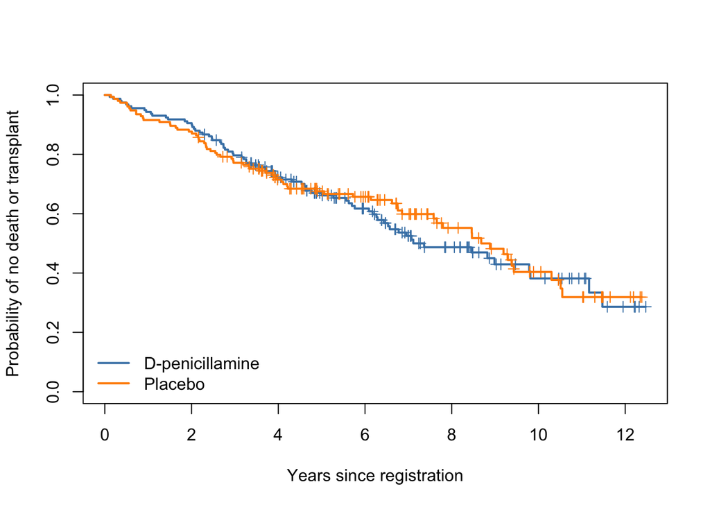

```r
plot(km_fit,
     col = c("steelblue", "darkorange"),
     lwd = 2,
     mark.time = TRUE,
     xlab = "Years since registration",
     ylab = "Probability of no death or transplant")
legend("bottomleft",
       legend = levels(pbc_trial$trt),
       col = c("steelblue", "darkorange"),
       lwd = 2, bty = "n")
```

```r
survdiff(Surv(time_years, event) ~ trt, data = pbc_trial)
```

```
Call:
survdiff(formula = Surv(time_years, event) ~ trt, data = pbc_trial)

                      N Observed Expected (O-E)^2/E (O-E)^2/V
trt=D-penicillamine 158       75     72.9    0.0595     0.121
trt=Placebo         154       69     71.1    0.0611     0.121

 Chisq= 0.1  on 1 degrees of freedom, p= 0.7
```

The Kaplan-Meier curves for the two treatment groups overlap throughout follow-up and cross several times. Median time to death or transplant was 7.1 years (95% CI 6.4–11.2) in the D-penicillamine group and 8.7 years (95% CI 7.7–10.5) in the placebo group, with widely overlapping confidence intervals. The log-rank test showed no evidence of a difference between groups (χ² = 0.1, df = 1, p = 0.7). Estimates beyond about 10 years are less reliable because few patients remained at risk.

## 5. Cox proportional hazards model

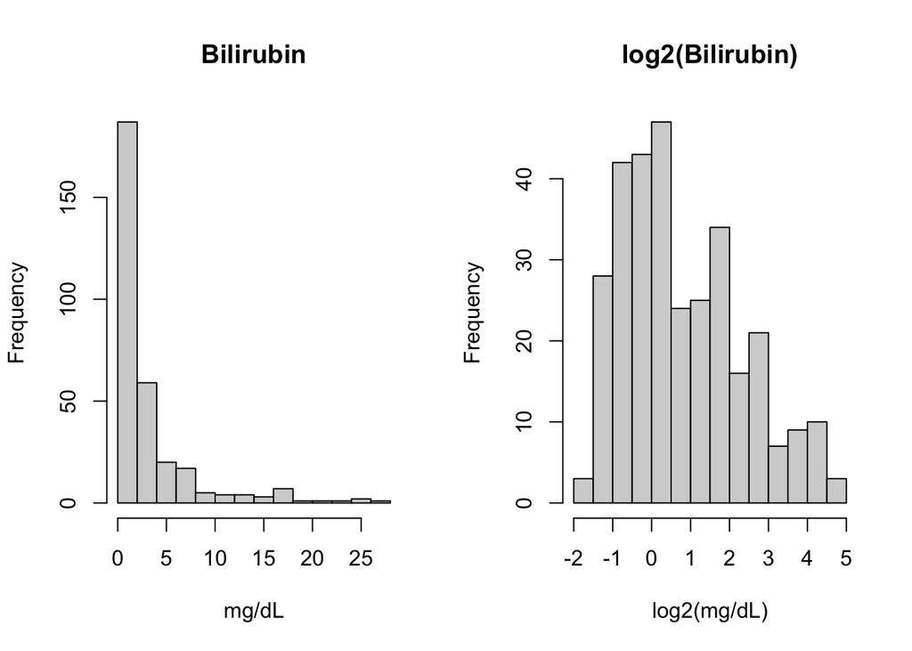

```r
par(mfrow = c(1, 2))
hist(pbc_trial$bili, main = "Bilirubin", xlab = "mg/dL")
hist(log2(pbc_trial$bili), main = "log2(Bilirubin)", xlab = "log2(mg/dL)")
```

```r
par(mfrow = c(1, 1))
```

```r
cox_fit <- coxph(Surv(time_years, event) ~ trt + age + sex + log2(bili) + albumin,
                 data = pbc_trial)
summary(cox_fit)
```

```
Call:
coxph(formula = Surv(time_years, event) ~ trt + age + sex + log2(bili) +
    albumin, data = pbc_trial)

  n= 312, number of events= 144

                coef exp(coef)  se(coef)      z Pr(>|z|)
trtPlacebo  0.068734  1.071151  0.171582  0.401   0.6887
age         0.019055  1.019237  0.008367  2.277   0.0228 *
sexf       -0.347322  0.706578  0.235456 -1.475   0.1402
log2(bili)  0.667392  1.949147  0.062813 10.625  < 2e-16 ***
albumin    -1.112747  0.328655  0.215623 -5.161 2.46e-07 ***
---
Signif. codes:  0 '***' 0.001 '**' 0.01 '*' 0.05 '.' 0.1 ' ' 1

           exp(coef) exp(-coef) lower .95 upper .95
trtPlacebo    1.0712     0.9336    0.7652    1.4993
age           1.0192     0.9811    1.0027    1.0361
sexf          0.7066     1.4153    0.4454    1.1209
log2(bili)    1.9491     0.5130    1.7234    2.2045
albumin       0.3287     3.0427    0.2154    0.5015

Concordance= 0.815  (se = 0.018 )
Likelihood ratio test= 179.8  on 5 df,   p=<2e-16
Wald test            = 176.7  on 5 df,   p=<2e-16
Score (logrank) test = 210.7  on 5 df,   p=<2e-16
```

Bilirubin was strongly right-skewed, so it was entered on the log2 scale; hazard ratios for bilirubin therefore refer to a doubling of its value. After adjustment, treatment was not associated with the hazard of death or transplant (HR for placebo vs D-penicillamine 1.07, 95% CI 0.77–1.50, p = 0.69), consistent with the log-rank test. Bilirubin was the strongest predictor: each doubling was associated with a near two-fold increase in hazard (HR 1.95, 95% CI 1.72–2.20). Higher albumin was protective (HR 0.33 per 1 g/dL, 95% CI 0.22–0.50), and older age was associated with higher hazard (HR 1.02 per year, 95% CI 1.00–1.04; roughly 21% per decade). The hazard was lower in women, but this was not statistically significant (HR 0.71, 95% CI 0.45–1.12), possibly reflecting the small number of men in the trial. The model showed good discrimination (concordance 0.82).

## 6. Checking the proportional hazards assumption

```r
ph_test <- cox.zph(cox_fit)
ph_test
```

```
            chisq df    p
trt        0.4161  1 0.52
age        0.6546  1 0.42
sex        0.0379  1 0.85
log2(bili) 0.2532  1 0.61
albumin    1.8617  1 0.17
GLOBAL     3.7331  5 0.59
```

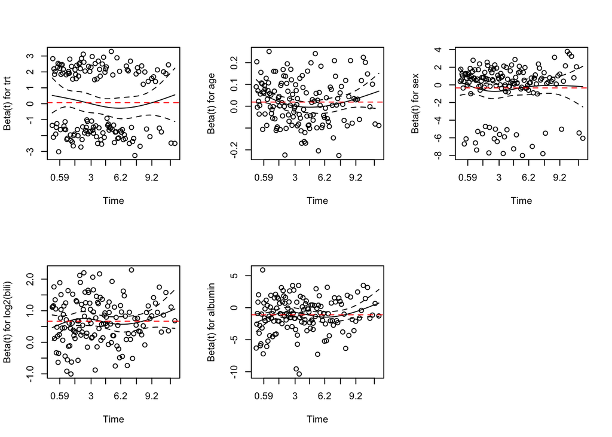

```r
par(mfrow = c(2, 3))
for (i in 1:5) {
  plot(ph_test[i])
  abline(h = coef(cox_fit)[i], col = "red", lty = 2)
}
```

The proportional hazards assumption was assessed using scaled Schoenfeld residuals. There was no evidence of violation for any covariate (all p > 0.15) or globally (p = 0.59). The smoothed residual plots were broadly flat for all covariates; the albumin curve suggested a slight weakening of its protective effect later in follow-up, but this was not statistically significant (p = 0.17). Wider confidence bands at later times reflect the smaller number of patients still at risk.

## 7. Discussion

### Main findings

D-penicillamine showed no benefit over placebo, either in the unadjusted Kaplan-Meier comparison or after adjustment for other covariates. In contrast, markers of liver function were strong prognostic factors: higher bilirubin and lower albumin were both associated with a substantially higher hazard of death or transplant, and older age was associated with a modest increase in hazard. The model discriminated well (concordance 0.82), and the proportional hazards assumption appeared reasonable.

### Limitations

- **Composite endpoint.** Death and transplant were combined into a single event. Transplant is a treatment decision rather than a disease outcome, and it prevents death from liver disease from being observed. A competing-risks approach (e.g. cause-specific hazards or Fine-Gray models) would separate the two outcomes.
- **Linearity.** Age, log2(bilirubin) and albumin were assumed to act linearly on the log-hazard; this was not formally checked (e.g. with martingale residuals or splines).
- **Small number of men**, which limits the precision of the sex effect.
- **Historical data.** The trial predates current treatment (ursodeoxycholic acid), so absolute risks may not apply to patients today.

## References

- Therneau TM, Grambsch PM (2000). *Modeling Survival Data: Extending the Cox Model*. Springer.
- Dickson ER, Grambsch PM, Fleming TR, Fisher LD, Langworthy A (1989). Prognosis in primary biliary cirrhosis: model for decision making. *Hepatology*, 10(1), 1–7.
- Therneau T (2024). *A Package for Survival Analysis in R*. R package `survival`.